# Predicting wellness of physical exercise (weight lifting)

Andra

28 Feb 2016

# Background

Using devices such as Jawbone Up, Nike FuelBand, and Fitbit it is now possible to collect a large amount of data about personal activity relatively inexpensively. These type of devices are part of the quantified self movement – a group of enthusiasts who take measurements about themselves regularly to improve their health, to find patterns in their behavior, or because they are tech geeks. One thing that people regularly do is quantify how much of a particular activity they do, but they rarely quantify how well they do it. In this project, your goal will be to use data from accelerometers on the belt, forearm, arm, and dumbell of 6 participants. They were asked to perform barbell lifts correctly and incorrectly in 5 different ways. More information is available from the website here: http://groupware.les.inf.puc-rio.br/har (see the section on the Weight Lifting Exercise Dataset).

## Scope

The main purpose of this project is to model how well individuals are exercising and to predict using the model how well new individuals will train using weights. The outcome (classe in our dataset) that we are trying to predict can take 5 values : A, B, C, D and E.

## Data Used

The data for this project come from this source: http://groupware.les.inf.puc-rio.br/har.

The training data for this project are available here:

https://d396qusza40orc.cloudfront.net/predmachlearn/pml-training.csv

The test data are available here:

https://d396qusza40orc.cloudfront.net/predmachlearn/pml-testing.csv

```r
trainUrl <- "http://d396qusza40orc.cloudfront.net/predmachlearn/pml-training.csv"
testUrl <- "http://d396qusza40orc.cloudfront.net/predmachlearn/pml-testing.csv"

#reading training and testing data and marking NA or empty fields as NA
training <- read.csv(url(trainUrl), na.strings=c("NA",""," "))
testing <- read.csv(url(testUrl), na.strings=c("NA"," ",""))

dim(training)
```

```
## [1] 19622   160
```

```r
dim(testing)
```

```
## [1]  20 160
```

## Data Cleaning

```r
noofnas<-apply(training, 2, function(x) length(which(is.na(x)))) # calculating the number of NA variables for each column
threshold<-0.7*nrow(training) # set threshold for variables to be removed: variables that have more than 70% NAs across all observations

noofnas<-subset(noofnas,noofnas<=threshold) # removing variables that do not fulfill condition above from our vector

training<-training[,names(noofnas)] # removing the variables that do not fulfill the % of NA condition
dim(training)
```

```
## [1] 19622    60
```

```r
timestamps.columns<-names(training)[3:5] # removing timestamps from model; timestamp is not a valid variable for predicting the wellness of exercise ; an option would be to actually create a time of the day variable (categorical) to see how well the time of the day affects the wellness

training<-training[, -which(names(training) %in% c("X","user_name", timestamps.columns))]
dim(training)
```

```
## [1] 19622    55
```

```r
temp<- training[, -which(names(training) %in% c("X","user_name","classe"))] # creating temp data frame to extract relevant columns from testing set
testing<-testing[,c(names(temp),"problem_id")]

dim(testing)
```

```
## [1] 20 55
```

Next, we need to make sure that the type (class) for each of the variables in the two data frames (training and testing) are the same . We consider data until length-1, as the last element is the prediction class and problem_id respectively . In order to do that, we are sorting the columns from the two datasets and then compare the types for each of the columns. For the ones that are different, we assign the right type. This will ensure that we will not have any unpleasant suprises when running the algorithms.

```r
temp<-training[, 1:ncol(training)-1]
temp<-temp[, order(names(temp))]
training<-cbind(temp, training$classe)
colnames(training)[length(training)]<-"classe"


temp<-testing[, 1:ncol(testing)-1]
temp<-temp[, order(names(temp))]
testing<-cbind(temp, testing$problem_id)
colnames(testing)[length(testing)]<-"problem_id"


classes.testing<-lapply(testing,class)
classes.training<-lapply(training,class)

classes.testing<-unlist(classes.testing)
classes.training<-unlist(classes.training)

test.class<-classes.testing[1:length(classes.testing)-1]==classes.training[1:length(classes.training)-1]
dif<-names(test.class[test.class==FALSE])

print(dif)
```

```
## [1] "magnet_dumbbell_z" "magnet_forearm_y"  "magnet_forearm_z"
```

```r
## there are 3 columns with a different type in the training set compared to the testing set
##separate test has showed that the columns in the testing set are "integer", whereas in the training set they are numeric
#we thus assign the right type

for (i in 1: length(dif))
   class(training[,dif[i]])<-"integer"
```

# Partitioning training data set

Further, we are partitioning our training data set into training set (60%) for fitting the model and testing set (40%) for testing our model .

```r
library(caret)
library(rattle)
library(rpart)
library(rpart.plot)
library (MASS)
library(pgmm)
library(randomForest)
library(e1071)
library(kernlab)
```

```r
inTrain <- createDataPartition(y=training$classe, p=0.6, list=FALSE)
training.new <- training[inTrain, ]
testing.new <- training[-inTrain, ]
dim(training.new)
```

```
## [1] 11776    55
```

```r
dim(testing.new)
```

```
## [1] 7846   55
```

```r
levels(testing$new_window ) <- levels(training.new$new_window) #ensure the same levels for the factor variables
```

# Prediction with Random Forrest

```r
set.seed(12345)

# Fitting the model
rf <- randomForest(classe ~ ., data=training.new, method="class")


# testing the model on our prediction data set

mypredictions<- predict(rf,  testing.new, type = "class")

# Results from testing the model : predicted versus observed
cfx<-confusionMatrix(mypredictions, testing.new$classe)
cfx
```

```
## Confusion Matrix and Statistics
##
##           Reference
## Prediction    A    B    C    D    E
##          A 2232    3    0    0    0
##          B    0 1510    4    0    0
##          C    0    5 1364   11    0
##          D    0    0    0 1274    6
##          E    0    0    0    1 1436
##
## Overall Statistics
##
##                Accuracy : 0.9962
##                  95% CI : (0.9945, 0.9974)
##     No Information Rate : 0.2845
##     P-Value [Acc > NIR] : < 2.2e-16
##
##                   Kappa : 0.9952
##  Mcnemar's Test P-Value : NA
##
## Statistics by Class:
##
##                      Class: A Class: B Class: C Class: D Class: E
## Sensitivity            1.0000   0.9947   0.9971   0.9907   0.9958
## Specificity            0.9995   0.9994   0.9975   0.9991   0.9998
## Pos Pred Value         0.9987   0.9974   0.9884   0.9953   0.9993
## Neg Pred Value         1.0000   0.9987   0.9994   0.9982   0.9991
## Prevalence             0.2845   0.1935   0.1744   0.1639   0.1838
## Detection Rate         0.2845   0.1925   0.1738   0.1624   0.1830
## Detection Prevalence   0.2849   0.1930   0.1759   0.1631   0.1832
## Balanced Accuracy      0.9997   0.9970   0.9973   0.9949   0.9978
```

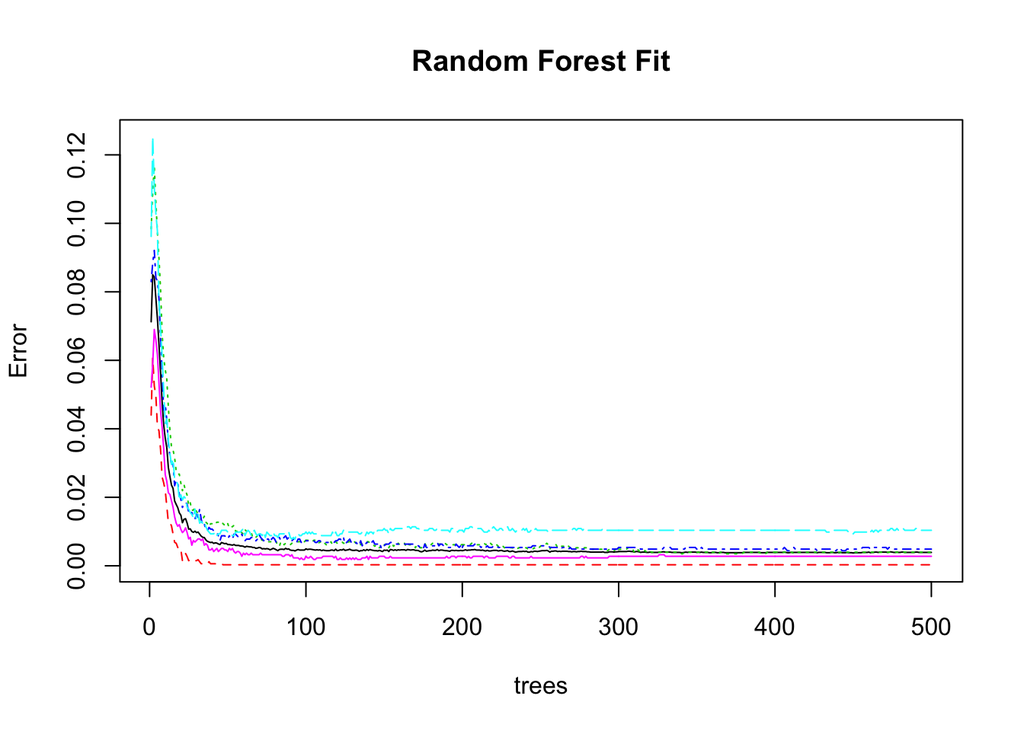

```r
plot(rf, main="Random Forest Fit")
```

## Results :

```r
cfx$overall
```

```
##       Accuracy          Kappa  AccuracyLower  AccuracyUpper   AccuracyNull
##      0.9961764      0.9951634      0.9945460      0.9974188      0.2844762
## AccuracyPValue  McnemarPValue
##      0.0000000            NaN
```

# Prediction with Support Vector Machines

```r
set.seed(12345)
# Fitting the model
sv <- svm(classe ~ ., data=training.new, method="class")


# testing the model on our prediction data set

mypredictions<- predict(sv,  testing.new, type = "class")

# Results from testing the model : predicted versus observed
cfx<-confusionMatrix(mypredictions, testing.new$classe)
cfx
```

```
## Confusion Matrix and Statistics
##
##           Reference
## Prediction    A    B    C    D    E
##          A 2195  117    1    0    0
##          B   16 1354   55    0   10
##          C   18   38 1294  129   35
##          D    1    2   17 1155   42
##          E    2    7    1    2 1355
##
## Overall Statistics
##
##                Accuracy : 0.9372
##                  95% CI : (0.9316, 0.9424)
##     No Information Rate : 0.2845
##     P-Value [Acc > NIR] : < 2.2e-16
##
##                   Kappa : 0.9204
##  Mcnemar's Test P-Value : < 2.2e-16
##
## Statistics by Class:
##
##                      Class: A Class: B Class: C Class: D Class: E
## Sensitivity            0.9834   0.8920   0.9459   0.8981   0.9397
## Specificity            0.9790   0.9872   0.9660   0.9905   0.9981
## Pos Pred Value         0.9490   0.9436   0.8547   0.9491   0.9912
## Neg Pred Value         0.9933   0.9744   0.9883   0.9802   0.9866
## Prevalence             0.2845   0.1935   0.1744   0.1639   0.1838
## Detection Rate         0.2798   0.1726   0.1649   0.1472   0.1727
## Detection Prevalence   0.2948   0.1829   0.1930   0.1551   0.1742
## Balanced Accuracy      0.9812   0.9396   0.9560   0.9443   0.9689
```

## Results :

```r
cfx$overall
```

```
##       Accuracy          Kappa  AccuracyLower  AccuracyUpper   AccuracyNull
##   9.371654e-01   9.204285e-01   9.315679e-01   9.424355e-01   2.844762e-01
## AccuracyPValue  McnemarPValue
##   0.000000e+00   4.963538e-49
```